# Discretization

## Discretizing the 2D Wave Equation

#### V. Hunter Adams (vha3@cornell.edu)

This is a supplemental document to support the drum synthesis lab for ECE 5760.

```python
HTML('''<script>
code_show=true;
function code_toggle() {
 if (code_show){
 $('div.input').hide();
 } else {
 $('div.input').show();
 }
 code_show = !code_show
}
$( document ).ready(code_toggle);
</script>
<form action="javascript:code_toggle()"><input type="submit" value="Show code."></form>''')
```

## The 2D Wave Equation

### Video discussion of the content on this page

[video not shown]

### Discretizing

A wave equation relates time derivatives to spatial derivatives. The continuous form for the 2D wave equation is given below. In this equation, $c$ is the speed of sound in the medium, $\eta$ is the viscosity coefficient, and $u$ is the out-of-plane amplitude of the node.

\begin{align} \frac{1}{c^2} \frac{\partial^2{u}}{\partial{t}^2} = \frac{\partial^2{u}}{\partial{x^2}} + \frac{\partial^2{u}}{\partial{y^2}} - \eta \frac{\partial{u}}{\partial{t}} \end{align}

In order to discretize this equation, recall the definition of a derivative and its difference approximation:

\begin{align} \frac{d}{dt}u(t) &= \lim_{\Delta t \rightarrow 0} \frac{u(t + \Delta t) - u(t)}{\Delta t}\\ &\approx \frac{u(t + \Delta t) - u(t)}{\Delta t} \end{align}

And recall the difference approximation for a second derivative:

\begin{align} \frac{d^2}{dt^2} u(t) &= \frac{ \frac{u(t + \Delta t) - u(t)}{\Delta t} - \frac{u(t) - u(t - \Delta t)}{\Delta t}}{\Delta t}\\ &= \frac{u(t + \Delta t) - 2 u(t) + u(t - \Delta t)}{\Delta t^2} \end{align}

Let us introduce a little notation for tidiness

[figure not shown]

Using the notation introduce above, we can rewrite the difference approximation for the second derivative a bit more concisely:

\begin{align} \frac{d^2}{dt^2}u(t) &= \frac{u_{i,j}^{n+1} - 2u_{i,j}^n + u_{i,j}^{n-1}}{\Delta t^2} \end{align}

The same difference approximation can be applied to spatial derivatives. Substituting into the continuous wave equation yields the following difference approximation for the 2D wave equation:

\begin{align} \frac{1}{c^2}\left[\frac{u_{i,j}^{n+1} - 2u_{i,j}^n + u_{i,j}^{n-1}}{\Delta t^2}\right] &= \frac{u_{i+1,j}^n - 2u_{i,j}^n + u_{i-1,j}^n}{\Delta x^2} + \frac{u_{i,j+1}^n - 2u_{i,j}^n + u_{i,j-1}^n}{\Delta y^2} - \eta\left(\frac{u_{i,j}^{n+1} - u_{i,j}^{n-1}}{2\Delta t}\right) \end{align}

We're going to solve this equation for $u_{i,j}^{n+1}$. But let's first define a parameter. This parameter is a normalized speed of sound in the medium. For the system to be stable (satisfy the [Courant-Friedrichs-Lewy condition](https://en.wikipedia.org/wiki/Courant–Friedrichs–Lewy_condition) it must be less than 0.5.

\begin{align} \rho = \left(\frac{c \Delta t}{\Delta x}\right)^2 < 0.5 \end{align}

With this parameter defined, we can solve the above equation for the updated $n+1$ node:

\begin{align} u_{i,j}^{n+1} &= \left[1 + \frac{\eta \Delta t}{2}\right]^{-1}\left\{ \rho\left[ u_{i+1,j}^n + u_{i-1,j}^n + u_{i,j-1}^n + u_{i,j+1}^n - 4u_{i,j}^n\right] + 2u_{i,j}^n - \left[1 - \frac{\eta \Delta t}{2}\right]u_{i,j}^{n-1}\right\} \end{align}

### Pitch Glide

In a real drum, the speed of sound through the drum is nonlinearly related to the tension in the membrane. We can make the simulation more realistic by calculating $\rho$ each time the drum is updated using the following equation:

\begin{align} \rho_{eff} = \text{min}\left(0.49, \rho_0 +[u_{i,j} \cdot G_{tension}]^2\right) \end{align}

### Simplification

In the case that $\frac{\eta \Delta t}{2}$ is small, then the first term in the discretized form of the 2D wave equation can be approximated by the first-order Taylor expansion.

\begin{align} \left[1 + \frac{\eta \Delta t}{2}\right]^{-1} \approx \left[1 - \frac{\eta \Delta t}{2}\right] \end{align}

This yields the following simplified version of the disretized equation:

\begin{align} u_{i,j}^{n+1} &= \left[1 - \frac{\eta \Delta t}{2}\right]\left\{ \rho\left[ u_{i+1,j}^n + u_{i-1,j}^n + u_{i,j-1}^n + u_{i,j+1}^n - 4u_{i,j}^n\right] + 2u_{i,j}^n - \left[1 - \frac{\eta \Delta t}{2}\right]u_{i,j}^{n-1}\right\} \end{align}

### Simulation

The second simulation uses a nonlinear (and exaggerated) rho for a very audible pitch glide.

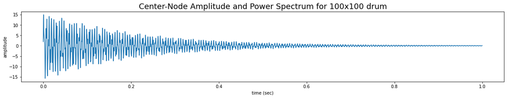

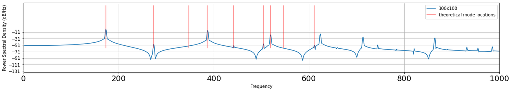

```
Audio - Python synthesized, constant value for rho, 100x100 drum
```

[interactive chart not shown]

```python
from IPython.display import Audio
import numpy
import matplotlib.pyplot as plt
from IPython.display import HTML
plt.rcParams["figure.figsize"] = (20,3)
%matplotlib inline

# Initializize drum
n = 100 ;
u = numpy.zeros((n,n));
u1 = numpy.zeros((n,n));
u2 = numpy.zeros((n,n));
uHit = numpy.zeros((n,n));

# Set rho, sample rate, and simulation time
rho = 0.25;
rho_eff = 0.25;
Fs = 48000 ;
time = numpy.arange(0, 1, (1./Fs))

# Array in which to store audio samples
aud = numpy.zeros(len(time)) ;

# Compute middle nodes
x_mid = int(n/2.);
y_mid = int(n/2.);

# Initialize drum amplitudes to a pyramid
for i in range(1, n-1):
    for j in range(1,n-1):
        uHit[i,j] = max(0, 30-(abs(x_mid - i) + abs(y_mid - j)))/30.;

# Zero boundary conditions
uHit[0,:] = 0
uHit[n-1,:] = 0
uHit[:,0] = 0
uHit[:,n-1] = 0

# Indexing variable
tindex = 0;

# Loop through time array
for t in time:

    u = numpy.zeros((n,n))

    # Hit the drum at t=0
    if (t==0):
        u1 = u1 + uHit;

    # Compute updated drum amplitudes
    u[1:n-2,1:n-2] = (1./(1+.0001)) * (rho_eff * (u1[2:n-1,1:n-2]+
                                      u1[0:n-3,1:n-2]+
                                      u1[1:n-2,2:n-1]+
                                      u1[1:n-2,0:n-3]-
                                      4*u1[1:n-2,1:n-2])
                               + 2*u1[1:n-2,1:n-2]
                               - (1-.0001) * (u2[1:n-2,1:n-2]) ) ;

    # Amplitude of center node goes into audio array
    aud[tindex] = u[n//2,n//2] ;

    # Update/store drum state
    u2 = u1;
    u1 = u;

    # Update rho
#     rho_eff = min(0.49, rho + ((1./16)*u[n//2,n//2])**2.)

    # Iterate
    tindex = tindex + 1;


# Plot the center node amplitudes
plt.rcParams["figure.figsize"] = (20,3)
plt.plot(time, aud)
plt.xlabel('time (sec)')
plt.ylabel('amplitude')
plt.title('Center-Node Amplitude and Power Spectrum for 100x100 drum', fontsize=18)
plt.figsize=(20,3)
plt.show()

# Plot the power spectrum
plt.rcParams["figure.figsize"] = (20,3)
Pxxt, freqst = plt.psd(aud,
                     NFFT=len(aud),
                     Fs=48000,
                     window=numpy.hamming(len(aud)),
                     noverlap=50, label='100x100')

# Plot the theoretical mode locations
fundamental = 173
yvals = numpy.linspace(-60, 70)
modes = [1.58, 2.0, 2.24, 2.55, 2.92, 3.0, 3.16, 3.54]
plt.plot(numpy.ones(len(yvals))*fundamental,
             yvals,
             'red',
             alpha=0.5, label='theoretical mode locations')
for i in modes:
    plt.plot(numpy.ones(len(yvals))*fundamental*i,
             yvals,
             'red',
             alpha=0.5)

# Configure plots
plt.xlim([0,1000])
plt.xticks(size=18)
plt.legend(loc='best')
plt.show()

# Output audio
print("Audio - Python synthesized, constant value for rho, 100x100 drum")
Audio(aud, rate=48000)
```

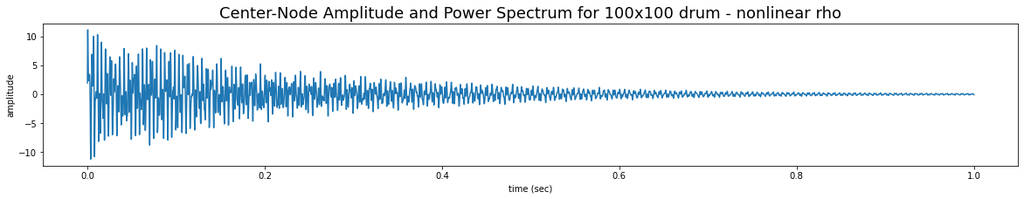

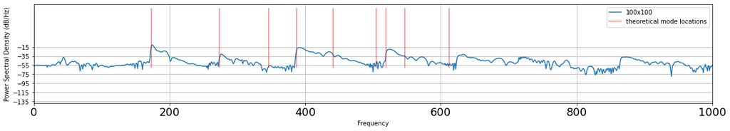

```
Audio - Python synthesized, nonlinear rho, 100x100 drum
```

[interactive chart not shown]

```python
# Initializize drum
n = 100 ;
u = numpy.zeros((n,n));
u1 = numpy.zeros((n,n));
u2 = numpy.zeros((n,n));
uHit = numpy.zeros((n,n));

# Set rho, sample rate, and simulation time
rho = 0.25;
rho_eff = 0.25;
Fs = 48000 ;
time = numpy.arange(0, 1, (1./Fs))

# Array in which to store audio samples
aud = numpy.zeros(len(time)) ;

# Compute middle nodes
x_mid = int(n/2.);
y_mid = int(n/2.);

# Initialize drum amplitudes to a pyramid
for i in range(1, n-1):
    for j in range(1,n-1):
        uHit[i,j] = max(0, 30-(abs(x_mid - i) + abs(y_mid - j)))/30.;

# Zero boundary conditions
uHit[0,:] = 0
uHit[n-1,:] = 0
uHit[:,0] = 0
uHit[:,n-1] = 0

# Indexing variable
tindex = 0;

# Loop through time array
for t in time:

    u = numpy.zeros((n,n))

    # Hit the drum at t=0
    if (t==0):
        u1 = u1 + uHit;

    # Compute updated drum amplitudes
    u[1:n-2,1:n-2] = (1./(1+.0001)) * (rho_eff * (u1[2:n-1,1:n-2]+
                                      u1[0:n-3,1:n-2]+
                                      u1[1:n-2,2:n-1]+
                                      u1[1:n-2,0:n-3]-
                                      4*u1[1:n-2,1:n-2])
                               + 2*u1[1:n-2,1:n-2]
                               - (1-.0001) * (u2[1:n-2,1:n-2]) ) ;

    # Amplitude of center node goes into audio array
    aud[tindex] = u[n//2,n//2] ;

    # Update/store drum state
    u2 = u1;
    u1 = u;

    # Update rho
    rho_eff = min(0.49, rho + ((1./16)*u[n//2,n//2])**2.)

    # Iterate
    tindex = tindex + 1;


# Plot the center node amplitudes
plt.rcParams["figure.figsize"] = (20,3)
plt.plot(time, aud)
plt.xlabel('time (sec)')
plt.ylabel('amplitude')
plt.title('Center-Node Amplitude and Power Spectrum for 100x100 drum - nonlinear rho', fontsize=18)
plt.figsize=(20,3)
plt.show()

# Plot the power spectrum
plt.rcParams["figure.figsize"] = (20,3)
Pxxt, freqst = plt.psd(aud,
                     NFFT=len(aud),
                     Fs=48000,
                     window=numpy.hamming(len(aud)),
                     noverlap=50, label='100x100')

# Plot the theoretical mode locations
fundamental = 173
yvals = numpy.linspace(-60, 70)
modes = [1.58, 2.0, 2.24, 2.55, 2.92, 3.0, 3.16, 3.54]
plt.plot(numpy.ones(len(yvals))*fundamental,
             yvals,
             'red',
             alpha=0.5, label='theoretical mode locations')
for i in modes:
    plt.plot(numpy.ones(len(yvals))*fundamental*i,
             yvals,
             'red',
             alpha=0.5)

# Configure plots
plt.xlim([0,1000])
plt.xticks(size=18)
plt.legend(loc='best')
plt.show()

# Output audio
print("Audio - Python synthesized, nonlinear rho, 100x100 drum")
Audio(aud, rate=48000)
```

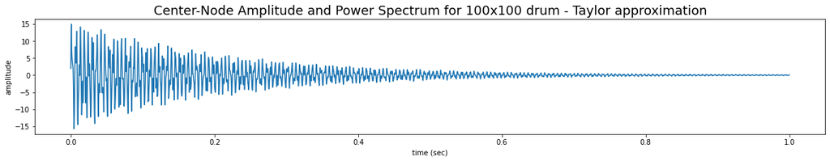

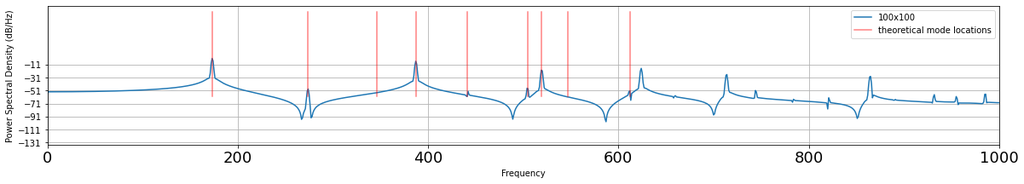

```
Audio - Python synthesized, constant value for rho, 100x100 drum - Taylor approximation
```

[interactive chart not shown]

```python
# Initializize drum
n = 100 ;
u = numpy.zeros((n,n));
u1 = numpy.zeros((n,n));
u2 = numpy.zeros((n,n));
uHit = numpy.zeros((n,n));

# Set rho, sample rate, and simulation time
# rho = 0.4;
rho_eff = 0.25;
Fs = 48000 ;
time = numpy.arange(0, 1, (1./Fs))

# Array in which to store audio samples
aud = numpy.zeros(len(time)) ;

# Compute middle nodes
x_mid = int(n/2.);
y_mid = int(n/2.);

# Initialize drum amplitudes to a pyramid
for i in range(1, n-1):
    for j in range(1,n-1):
        uHit[i,j] = max(0, 30-(abs(x_mid - i) + abs(y_mid - j)))/30.;

# Zero boundary conditions
uHit[0,:] = 0
uHit[n-1,:] = 0
uHit[:,0] = 0
uHit[:,n-1] = 0

# Indexing variable
tindex = 0;

# Loop through time array
for t in time:

    u = numpy.zeros((n,n))

    # Hit the drum at t=0
    if (t==0):
        u1 = u1 + uHit;

    # Compute updated drum amplitudes
    u[1:n-2,1:n-2] = ((1-.0001)) * (rho_eff * (u1[2:n-1,1:n-2]+
                                      u1[0:n-3,1:n-2]+
                                      u1[1:n-2,2:n-1]+
                                      u1[1:n-2,0:n-3]-
                                      4*u1[1:n-2,1:n-2])
                               + 2*u1[1:n-2,1:n-2]
                               - (1-.0001) * (u2[1:n-2,1:n-2]) ) ;

    # Amplitude of center node goes into audio array
    aud[tindex] = u[n//2,n//2] ;

    # Update/store drum state
    u2 = u1;
    u1 = u;

    # Update rho
#     rho_eff = min(0.49, rho + ((1./16)*u[n//2,n//2])**2.)

    # Iterate
    tindex = tindex + 1;


# Plot the center node amplitudes
plt.rcParams["figure.figsize"] = (20,3)
plt.plot(time, aud)
plt.xlabel('time (sec)')
plt.ylabel('amplitude')
plt.title('Center-Node Amplitude and Power Spectrum for 100x100 drum - Taylor approximation', fontsize=18)
plt.figsize=(20,3)
plt.show()

# Plot the power spectrum
plt.rcParams["figure.figsize"] = (20,3)
Pxxt, freqst = plt.psd(aud,
                     NFFT=len(aud),
                     Fs=48000,
                     window=numpy.hamming(len(aud)),
                     noverlap=50, label='100x100')

# Plot the theoretical mode locations
fundamental = 173
yvals = numpy.linspace(-60, 70)
modes = [1.58, 2.0, 2.24, 2.55, 2.92, 3.0, 3.16, 3.54]
plt.plot(numpy.ones(len(yvals))*fundamental,
             yvals,
             'red',
             alpha=0.5, label='theoretical mode locations')
for i in modes:
    plt.plot(numpy.ones(len(yvals))*fundamental*i,
             yvals,
             'red',
             alpha=0.5)

# Configure plots
plt.xlim([0,1000])
plt.xticks(size=18)
plt.legend(loc='best')
plt.show()

# Output audio
print("Audio - Python synthesized, constant value for rho, 100x100 drum - Taylor approximation")
Audio(aud, rate=48000)
```